# The Effect of COVID-19 on US Flights

2024-03-25

## 1. Research Question

How did the average flight delay time and number of flights change between JFK and LAX in the first quarter of 2019 compared to that of 2021?

## 2. Rationale for the Research Question

The research question was chosen primarily because JFK and LAX are two of the largest and busiest airports in the U.S., making them key hubs for both domestic and international flights. By focusing on these airports, the study aims to provide insights into the effect of COVID-19 on major air traffic flows across the U.S. The decision to compare the first quarters of 2019 and 2021 allows us to understand the specific impacts of the pandemic on air travel operations, since 2019 represents a normal operational period before COVID-19, while 2021 introduced pandemic-related restrictions like travel bans and quarantine mandates. This comparison will not only highlight how such conditions affected flight delays and the number of flights but also provide insights into how airlines and governments can improve their strategies and responses in future crises.

## 3. Data Selection

```r
library("anyflights")
library("dplyr")
```

```r
library(maps)
library(tidyverse)
library(nycflights13)
library(plotly)
library(knitr)
library(rmarkdown)

JFK19 <- get_flights("JFK", year=2019, month=1:3)
```

```
##                                 Total Time Elapsed
## Finished Processing Arguments                   1s
## Downloaded Flights Data for January            17s
## Downloaded Flights Data for February           31s
## Downloaded Flights Data for March              48s
## Finished Processing Flights Data               54s
```

```r
JFK21 <- get_flights("JFK", year=2021, month=1:3)
```

```
##                                 Total Time Elapsed
## Finished Processing Arguments                   0s
## Downloaded Flights Data for January            10s
## Downloaded Flights Data for February           19s
## Downloaded Flights Data for March              30s
## Finished Processing Flights Data               36s
```

```r
LAX19 <- get_flights("LAX", year=2019, month=1:3)
```

```
##                                 Total Time Elapsed
## Finished Processing Arguments                   0s
## Downloaded Flights Data for January            16s
## Downloaded Flights Data for February           36s
## Downloaded Flights Data for March              54s
## Finished Processing Flights Data               61s
```

```r
LAX21 <- get_flights("LAX", year=2021, month=1:3)
```

```
##                                 Total Time Elapsed
## Finished Processing Arguments                   0s
## Downloaded Flights Data for January            10s
## Downloaded Flights Data for February           21s
```

```
## Downloaded Flights Data for March              37s
## Finished Processing Flights Data               47s
```

```r
combined_data <- bind_rows(JFK19, JFK21, LAX19, LAX21)

write.csv(combined_data, "combined_flights.csv")
```

## 4. Analytical Approach and Visual Findings

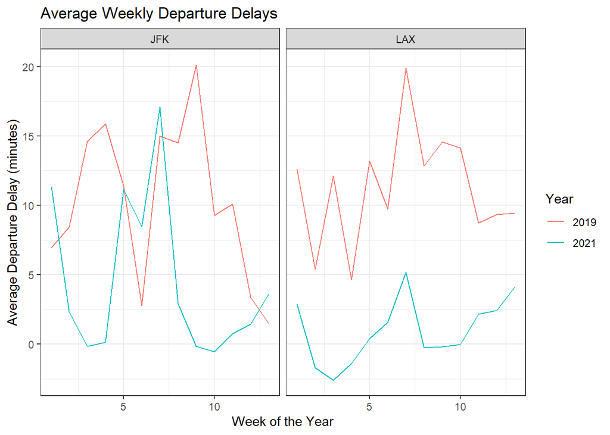

```r
#Average Departure Delay
combined_data %>%
  mutate(week = week(time_hour)) %>%
  group_by(year, origin, week) %>%
  summarise(avg_delay = mean(dep_delay, na.rm = TRUE), .groups = 'drop') %>%
  ggplot(aes(x = week, y = avg_delay, color = factor(year))) +
  geom_line() +
  theme_bw() +
  labs(title = 'Average Weekly Departure Delays',
       x = 'Week of the Year',
       y = 'Average Departure Delay (minutes)',
       color = 'Year')+
  facet_grid(~origin)
```

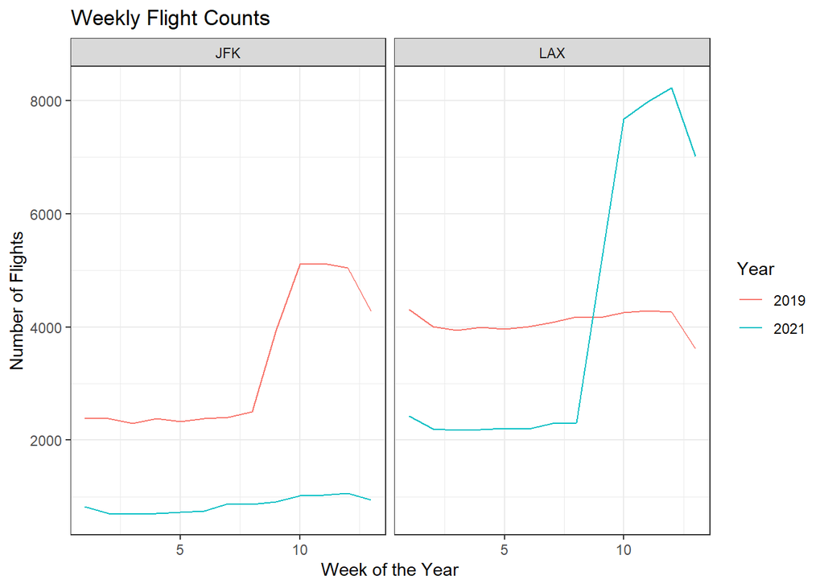

```r
#This calculates the average weekly departure delay in minutes for each airport with the two years being on the same graph. The average weekly departure delays show both airports witnessing an overall decrease in the delays of the flights. If observed more closely, JFK has overlaps of both years in delays whereas LAX has no overlaps at all. This implies that LAX has a slightly more significant decrease in comparison to JFK in regards to delay times.

#Number of flights
combined_data %>%
  mutate(week = week(time_hour)) %>%
  group_by(year, origin, week) %>%
  summarize(flights = n(), .groups = 'drop') %>%
  ggplot(aes(x = week, y = flights, color = factor(year))) +
  geom_line() +
  theme_bw() +
  labs(title = 'Weekly Flight Counts',
       x = 'Week of the Year',
       y = 'Number of Flights',
       color = 'Year')+
  facet_grid(~origin)
```